# 반도체 기술 심층분석 — 어드밴스드 패키징 (CoWoS, FOWLP, 2.5D/3D)

Alpha Hunter Tech Deep Dive #3 | 관련 종목: ONTO Innovation, ISC, ASE, Amkor

Author

Alpha Hunter × Chimera AI

Published

May 20, 2026

# 개요: 왜 어드밴스드 패키징인가

**핵심 메시지**

**어드밴스드 패키징**은 무어의 법칙이 물리적 한계에 부딪힌 시대의 새로운 성능 확장 축이다. 트랜지스터를 더 작게 만드는 대신, 여러 칩(chiplet)을 하나의 패키지 안에 **2.5D/3D로 통합**함으로써 성능, 대역폭, 전력효율을 동시에 달성한다. NVIDIA Blackwell, AMD MI300, Apple M4 Ultra 모두 어드밴스드 패키징 없이는 존재할 수 없다. AI 가속기 수요가 폭발하면서, CoWoS 생산능력은 2024년 35K wafer/월에서 2026년 130K wafer/월로 **3.7배** 증가할 전망이다.

반도체 산업은 **“More Moore”**(미세공정 축소)에서 **“More than Moore”**(이종 칩 통합)로 패러다임이 전환되고 있다. 어드밴스드 패키징은 이 전환의 핵심 기술이다. 서로 다른 공정 노드로 제작된 칩렛(로직, 메모리, I/O, 아날로그)을 실리콘 인터포저나 RDL(Redistribution Layer)을 통해 하나의 패키지로 통합하여, 모놀리식 SoC의 수율 한계와 비용 문제를 동시에 해결한다.

이 보고서는 어드밴스드 패키징의 핵심 기술—**CoWoS(2.5D)**, **FOWLP/FOPLP**, **3D SoIC**, **EMIB**—의 원리와 진화, 공급망 구조, 시장 전망을 심층 분석하고, 알파 헌터가 주목하는 관련 종목의 기술적 맥락을 제공한다.

# 1 패키징 기술 진화 타임라인

## 1.1 와이어본딩에서 3D 적층까지

전통적인 반도체 패키징은 칩과 기판을 금선(wire bond)으로 연결하는 단순 구조였다. 하지만 AI 시대의 고대역폭·저지연 요구는 완전히 새로운 패키징 패러다임을 요구한다.

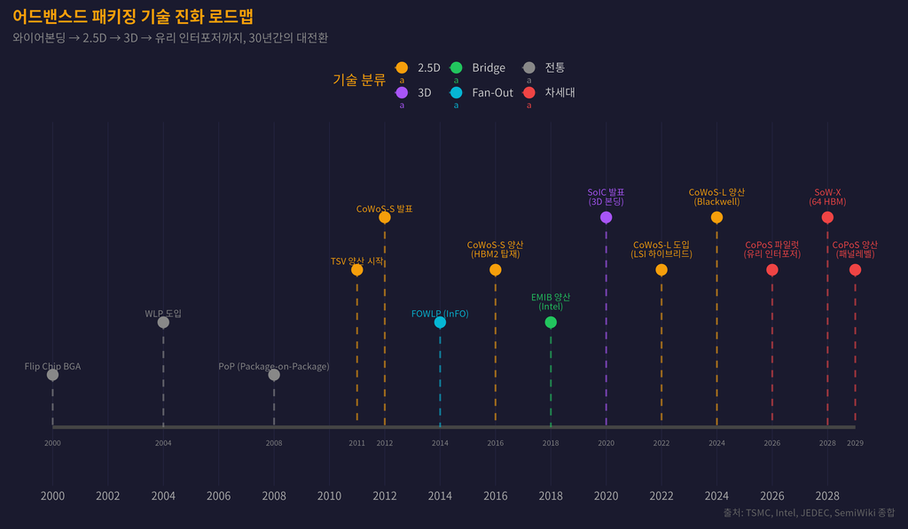

Figure 1: 어드밴스드 패키징 기술 진화 타임라인 (2000~2029)

## 1.2 기술 분류 체계

어드밴스드 패키징은 칩간 연결 방향에 따라 크게 세 가지로 분류된다:

- **2.5D 패키징**: XY 평면 확장. 실리콘 인터포저(CoWoS) 또는 RDL(InFO)을 통해 칩렛을 나란히 배치
- **3D 패키징**: Z축 적층. TSV를 통해 칩을 수직으로 쌓음 (SoIC, HBM)
- **Bridge 패키징**: 기판 내 소형 실리콘 브릿지로 칩렛 연결 (EMIB)

Table 1: 주요 어드밴스드 패키징 기술 비교

[output not shown]

# 2 CoWoS: AI 시대의 핵심 패키징

## 2.1 CoWoS의 원리

CoWoS(Chip-on-Wafer-on-Substrate)는 TSMC가 2012년 발표한 2.5D 패키징 기술이다. 핵심 구조는 다음과 같다:

1. **실리콘 인터포저**: 수만 개의 TSV(Through-Silicon Via)가 관통하는 얇은 실리콘 웨이퍼
2. **칩 배치 (Chip-on-Wafer)**: 로직 다이와 HBM을 인터포저 위에 나란히 배치
3. **기판 연결 (on-Substrate)**: 인터포저를 유기 기판에 접합하여 외부 인터페이스 제공

**CoWoS의 핵심 가치**

GPU-HBM 간 데이터 전송에서 **수천 개의 병렬 배선**을 제공하여, 기존 PCB 배선 대비 **10배 이상의 대역폭**과 **1/5의 전력소모**를 달성한다. NVIDIA H100의 GPU-HBM3 간 대역폭 3.35TB/s는 CoWoS 없이는 불가능하다.

## 2.2 CoWoS 변종 비교

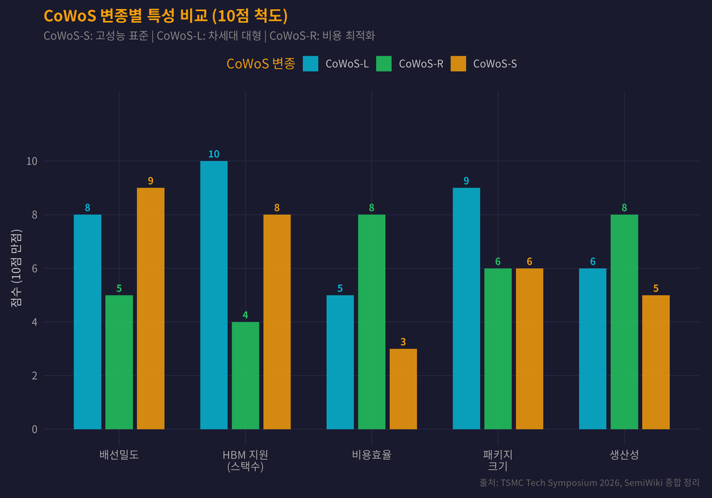

### 2.2.1 CoWoS-S → CoWoS-L 전환의 핵심

- **CoWoS-S**: 단일 실리콘 인터포저로 레티클 1~2개 크기. H100, MI300에 사용. 대형화에 한계
- **CoWoS-L**: LSI(Local Silicon Interconnect) + RDL 하이브리드 구조. 칩간 고밀도 연결이 필요한 부분에만 실리콘을 사용하고, 나머지는 RDL로 연결. **5.5 레티클 크기**까지 확장 가능하여 12개 이상의 HBM 스택 탑재 가능
- **CoWoS-R**: 실리콘 인터포저 없이 RDL만으로 구성. 비용이 낮지만 배선 밀도 한계. AI ASIC, 네트워크 칩 등 비용 민감 시장 타깃

## 2.3 CoWoS 생산능력 확장 추이

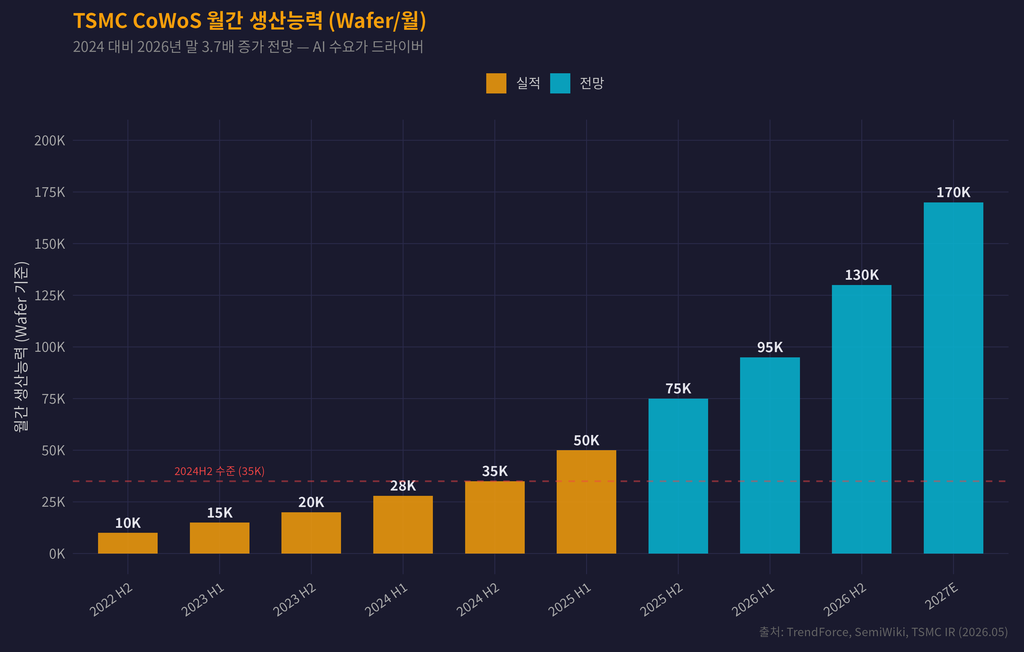

Figure 3: TSMC CoWoS 월간 생산능력 확장 추이 (2022~2027E)

**공급 병목 지속**

# 3 FOWLP/FOPLP: 비용 혁신의 축

## 3.1 Fan-Out 패키징의 원리

Fan-Out Wafer Level Packaging(FOWLP)은 칩을 몰드 수지(EMC)로 재구성한 뒤, **RDL(Redistribution Layer)**로 I/O를 팬아웃하여 패키지를 구성하는 기술이다.

- **기존 WLP(Fan-In)**: 칩 면적 = 패키지 면적 → I/O 수 제한
- **Fan-Out**: 칩 주변에 RDL을 확장하여 더 많은 I/O 확보, 인터포저 불필요

TSMC의 **InFO(Integrated Fan-Out)**가 대표적이며, Apple A시리즈/M시리즈 AP에 채택되어 iPhone/iPad의 박형화에 기여했다.

## 3.2 FOPLP (Fan-Out Panel Level Packaging)

FOWLP의 진화형으로, 원형 웨이퍼(300mm) 대신 **대형 직사각형 패널**(~600×600mm)에서 패키징을 수행한다.

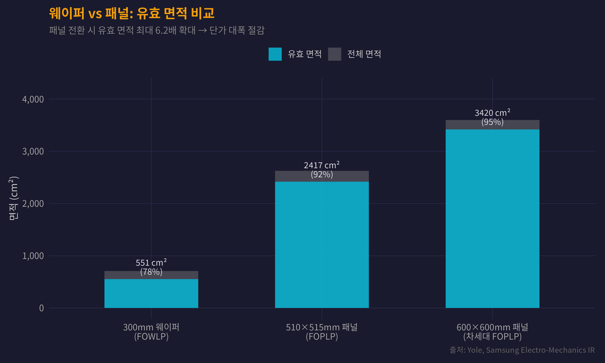

Figure 4: 웨이퍼 vs 패널 면적 활용률 비교

패널 레벨 패키징의 핵심 가치는 **비용 절감**이다:

- 원형 웨이퍼의 가장자리 손실(~22%) vs 직사각형 패널(~5%)
- 600×600mm 패널은 300mm 웨이퍼 대비 유효 면적 **6배 이상**
- 비용 절감 효과: 패키지당 **30~50%** 원가 절감 가능

Samsung, ASE, Amkor 등이 FOPLP 양산을 확대 중이며, 주로 PMIC(전력관리IC), 센서, 중저가 AP에 적용 중이다.

# 4 3D 패키징: Z축의 혁명

## 4.1 SoIC (System on Integrated Chips)

TSMC의 SoIC는 진정한 **3D 적층** 기술이다. CoWoS가 칩을 나란히 배치하는 2.5D라면, SoIC는 칩을 **수직으로 쌓는다**.

핵심 특징:

- **Direct Bond**: 마이크로 범프 없이 Cu-Cu 직접 본딩 → 범프 피치 극소화 (~1μm)
- **Face-to-Face / Face-to-Back**: 칩 방향에 따른 유연한 적층 구조
- **Hybrid Bonding**: 산화막(SiO₂) + 구리(Cu) 동시 접합으로 초미세 피치 실현

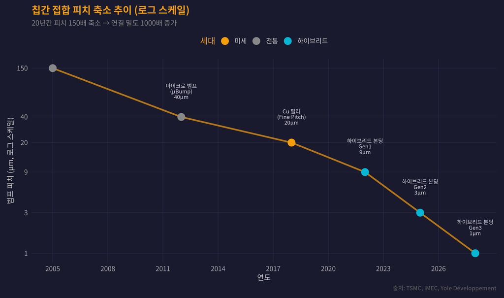

Figure 5: 칩간 접합 기술 진화: 범프 피치 축소 추이

## 4.2 3D 적층의 도전과제

3D 패키징은 높은 성능을 제공하지만, 해결해야 할 기술적 과제가 있다:

- **열 관리**: 칩 적층 시 발열 밀도 급증. 중간 다이 방열 경로 확보 필요
- **Known Good Die (KGD)**: 적층 전 모든 다이의 양품 검증 필수 → **검사 장비 수요 급증**
- **Warpage (휨)**: 이종 재료 열팽창 계수 차이로 웨이퍼 휨 발생
- **TSV 스트레스**: 실리콘 관통 비아 주변 기계적 응력으로 회로 특성 변화

**투자 시사점: 검사 장비의 중요성**

3D 적층에서 한 다이라도 불량이면 전체 스택이 폐기된다. **KGD 검증률이 수율을 결정**하며, 이는 곧 **계측/검사 장비(ONTO Innovation, KLA, ISC)**의 전략적 가치가 급등함을 의미한다.

# 5 차세대: CoPoS와 유리 인터포저

## 5.1 실리콘에서 유리로

현재 CoWoS의 실리콘 인터포저는 두 가지 한계가 있다:

1. **크기 제한**: 실리콘 웨이퍼 기반이므로 레티클 크기에 제약
2. **비용**: 실리콘 인터포저 자체가 고가의 반도체 공정 필요

**CoPoS(Chip-on-Panel-on-Substrate)**는 실리콘 인터포저를 **유리 인터포저(TGV: Through-Glass Via)**로 대체한다.

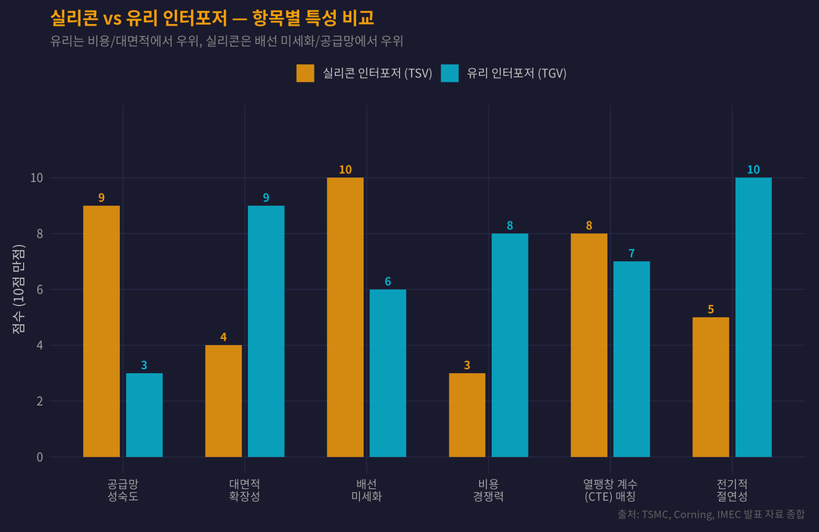

Figure 6: 실리콘 vs 유리 인터포저 특성 비교

## 5.2 CoPoS 타임라인

- **2026**: TSMC 파일럿 라인 가동 (Tainan AP8 fab)
- **2027~2028**: 제한적 양산 시작
- **2029**: 본격 양산 — SoW-X (64 HBM 스택) 적용 목표

유리 인터포저 기술이 상용화되면, 패키지 크기 제약이 대폭 완화되어 **웨이퍼 스케일** AI 가속기의 실현이 가까워진다.

# 6 경쟁 구도: TSMC vs Intel vs Samsung

## 6.1 패키징 기술 포트폴리오 비교

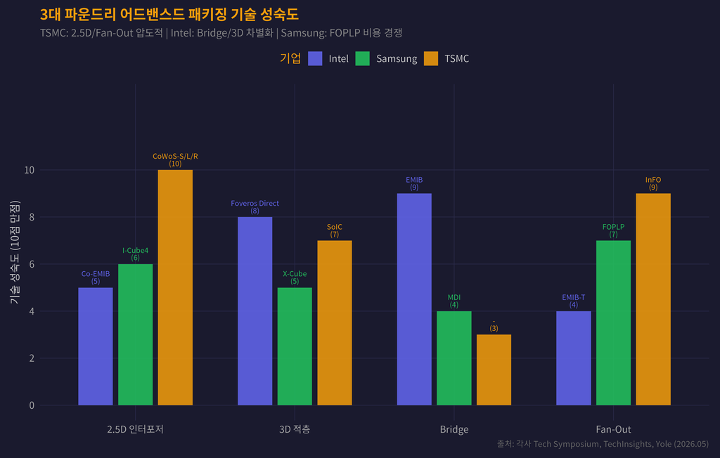

Figure 7: 3대 파운드리 어드밴스드 패키징 포트폴리오 비교

### 6.1.1 TSMC의 압도적 지배

TSMC는 CoWoS 시장의 **80% 이상**을 점유하고 있다. NVIDIA, AMD, Broadcom, Google, Amazon 등 주요 AI 가속기 기업이 모두 TSMC의 CoWoS를 사용한다. 이는 선단 로직 공정(3nm, 2nm)과 패키징을 한 곳에서 해결할 수 있는 **수직 통합**의 강점이다.

### 6.1.2 Intel의 차별화 전략

Intel은 EMIB(Embedded Multi-die Interconnect Bridge)로 차별화한다. 대형 실리콘 인터포저 대신 기판에 **소형 실리콘 브릿지를 내장**하여 칩렛을 연결한다.

- 패널 활용률: EMIB **~90%** vs CoWoS 인터포저 **~60%**
- 비용: CoWoS 대비 **30~40%** 절감
- 한계: 배선 밀도가 CoWoS보다 낮아 최고성능 AI 가속기에는 부적합

CoWoS 공급 부족으로 TSMC에서 용량을 확보하지 못한 기업들이 Intel의 EMIB 패키징을 대안으로 검토하고 있다.

# 7 시장 규모와 성장 전망

## 7.1 어드밴스드 패키징 시장 성장

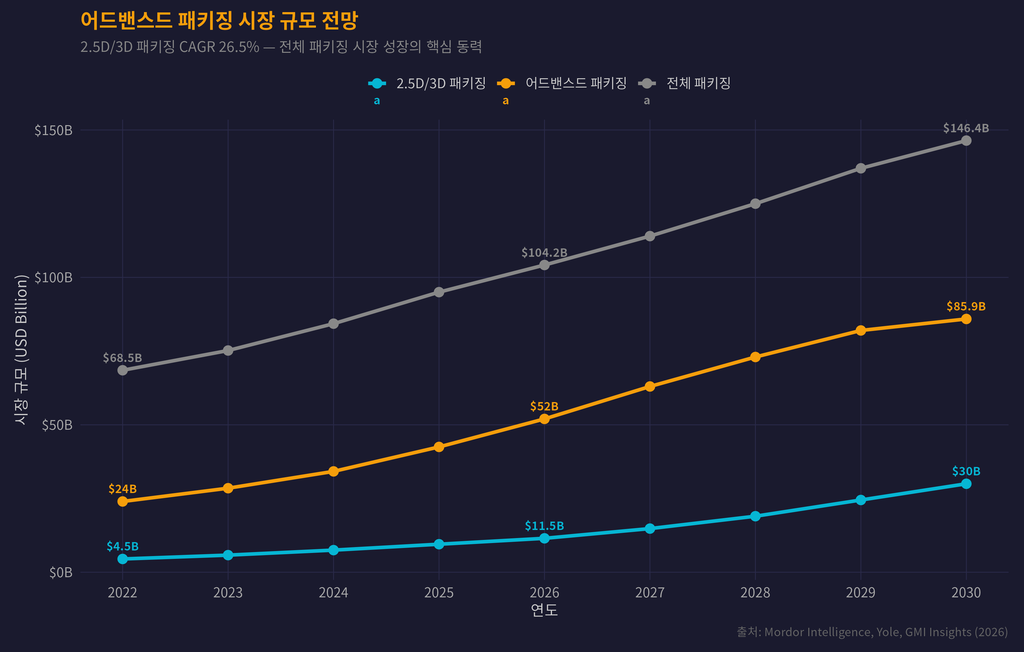

Figure 8: 어드밴스드 패키징 시장 규모 전망 (2022~2030)

## 7.2 CoWoS 수요 vs 공급 갭

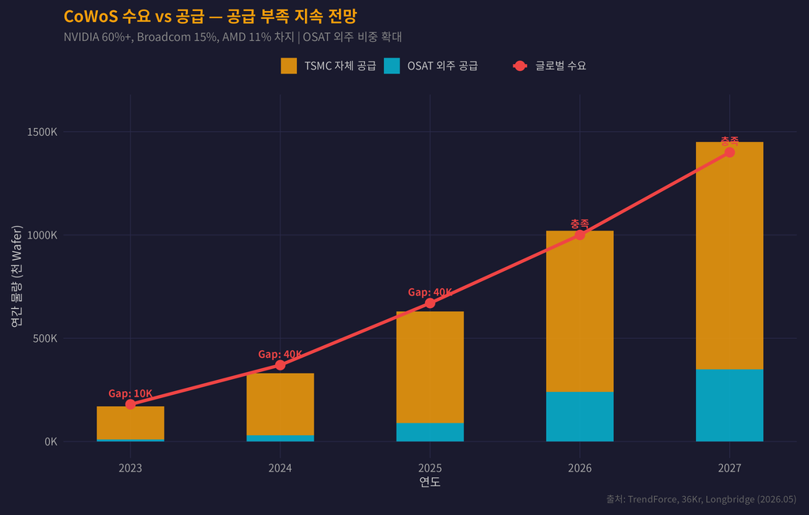

Figure 9: CoWoS 연간 수요 vs 공급 전망 (2023~2027E, 천 Wafer)

**CoWoS 수요 배분 (2026년 전망)**

- **NVIDIA**: ~60% (Blackwell, Rubin용 CoWoS-L 중심)
- **Broadcom**: ~15% (Google TPU, 네트워크 ASIC)
- **AMD**: ~11% (MI350 가속기)
- **기타**: ~14% (Amazon Trainium, Microsoft Maia, Meta MTIA 등)

# 8 공급망 밸류체인과 수혜 기업

## 8.1 어드밴스드 패키징 밸류체인

Table 2: 어드밴스드 패키징 밸류체인별 핵심 기업

[output not shown]

# 9 핵심 성능 지표: 세대별 비교

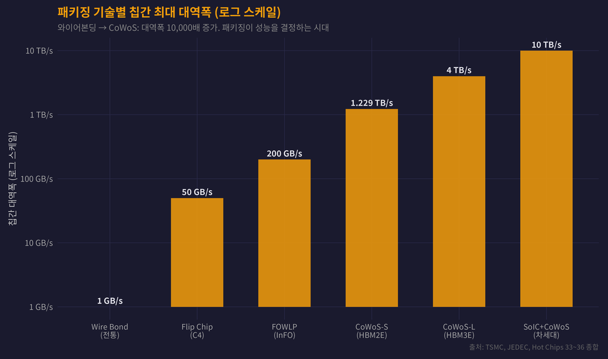

Figure 10: 어드밴스드 패키징 세대별 칩간 대역폭 진화

# 10 기술 구조도 해설

## 10.1 CoWoS-L 구조 상세

CoWoS-L은 현재 가장 주목받는 어드밴스드 패키징 기술이다. NVIDIA Blackwell B200에 적용되었으며, 그 구조를 단계별로 해설한다:

**Layer 1 — 유기 기판 (Organic Substrate)**

- FC-BGA(Flip-Chip Ball Grid Array) 기판
- 외부 PCB와의 전기적/물리적 연결 담당
- 층수 증가 추세: 12L → 16L → 20L+

**Layer 2 — 하이브리드 인터포저**

**Layer 3 — 칩렛 어레이**

- 중앙: GPU/가속기 다이 (3nm/2nm 공정)
- 주변: HBM4 스택 × 12개 이상 (36~48GB 용량)
- I/O 다이, SerDes 등 기능별 칩렛 통합 가능

**Layer 4 — 히트싱크/TIM**

- TDP 1000W+ 대응
- Thermal Interface Material(TIM) + Vapor Chamber

**핵심 인사이트**

CoWoS-L의 ‘하이브리드’ 접근법이 혁신적인 이유는 **비용과 성능의 최적 균형**을 달성하기 때문이다. 실리콘 인터포저를 필요한 곳에만 사용하고 나머지는 저비용 RDL로 처리하여, CoWoS-S 대비 **대형화는 3배, 비용은 1.5배**에 불과하다.

# 11 투자 시사점

## 11.1 수혜 기업 분석

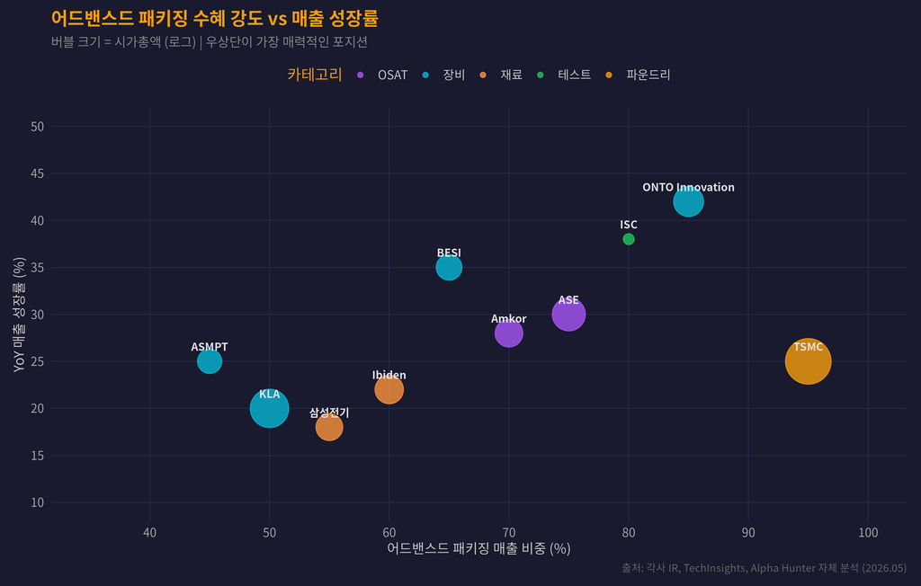

Figure 11: 어드밴스드 패키징 수혜 강도별 기업 분류

## 11.2 Alpha Hunter 히든젬과의 연결

### 11.2.1 ONTO Innovation (ONTO) — 계측/검사의 핵심

- **3D 계측**: CoWoS 인터포저의 TSV 깊이/직경, 범프 높이 측정
- **오버레이 검사**: 칩렛 배치 정밀도 검증
- **웨이퍼 인스펙션**: KGD 확보를 위한 다이 레벨 불량 검출
- Week 20 보고서에서 SEPA 7/7 통과, 매출성장률 42% 확인

### 11.2.2 ISC (095340) — 테스트 소켓의 글로벌 1위

- **번인 소켓**: HBM 스택, AI 가속기 패키지의 신뢰성 테스트
- **Test Socket**: 다양한 패키지 타입(BGA, LGA, QFN)에 대응
- **칩렛 시대**: 테스트 포인트 수 급증 → 소켓 수요 비례 증가
- Week 20 보고서에서 SEPA 7/7 통과, 글로벌 M/S 30%+ 확인

**핵심 투자 논리**

## 11.3 중장기 투자 체크리스트

Table 3: 어드밴스드 패키징 투자 체크리스트

[output not shown]

# 12 리스크 요인

1. **지정학적 리스크**: TSMC의 대만 집중 (CoWoS capa의 90%+ 대만). 미중 갈등 시 글로벌 AI 공급망 혼란
2. **기술 전환 리스크**: CoPoS(유리 인터포저)가 예상보다 빠르게 상용화되면 실리콘 인터포저 관련 투자 회수 어려움
3. **수요 변동 리스크**: AI 투자 사이클 둔화 시 CoWoS 수요 급감 가능. 과잉 capa 구축 리스크
4. **경쟁 심화**: Intel EMIB, Samsung I-Cube의 기술 성숙으로 TSMC 독점 약화 가능성
5. **비용 상승**: 어드밴스드 패키징 비용이 전체 칩 비용의 40~60% 차지 → 비용 전가 한계

# 13 결론

**보고서 요약**

어드밴스드 패키징은 **무어의 법칙 이후 시대의 성능 확장 엔진**이다. CoWoS를 중심으로 2.5D/3D 패키징 시장은 2026~2030년 CAGR 25%+ 성장이 예상되며, AI 가속기 수요가 핵심 동력이다. 투자자는 패키징 capa 확장의 **직접 수혜주**(TSMC, Amkor) 뿐 아니라, 공정 복잡도 증가에 따른 **필수 인프라**(ONTO Innovation의 계측, ISC의 테스트 소켓)에도 주목해야 한다. 특히 KGD 검증과 칩렛 테스트는 3D 적층 시대의 **수율 지킴이**로서, 패키징 투자 사이클의 가장 확실한 수혜 영역이다.

**면책 조항**

이 프로젝트는 가상 투자 시뮬레이션 목적으로 작성되었습니다. 실제 투자 권유가 아닙니다.